# Lab 3 - Trực quan hóa dữ liệu với ggplot2

### Câu 8.

Tạo lại biểu đồ sau và diễn giải những gì bạn thấy trong ngữ cảnh của dữ liệu.

**Gợi ý:** Trục `x` là một biến được tính toán. Một quốc gia có lượng rác thải nhựa bình quân đầu người trên 3 kg/ngày đã được lọc bỏ. Dữ liệu không chỉ được biểu diễn bằng các điểm trên biểu đồ mà còn là một đường cong mượt mà (smooth curve). Thuật ngữ “smooth” sẽ giúp bạn chọn hàm `geom` nào để sử dụng (https://ggplot2.tidyverse.org/reference/index.html#section-geoms).

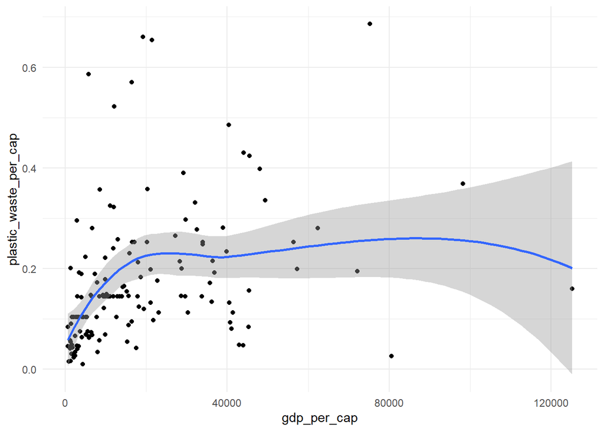

```r
plastic_waste %>%
  filter(plastic_waste_per_cap<=3)%>%
  ggplot(aes(x=gdp_per_cap, y=plastic_waste_per_cap))+
  geom_point()+
  geom_smooth()+
  theme_minimal()
```

*Nhận xét* - Có xu hướng dương nhẹ giữa GDP bình quân đầu người và lượng rác thải nhựa trên đầu người. - Các quốc gia có GDP cao thường có mức tiêu thụ và phát sinh rác thải nhựa cao hơn. - Tuy nhiên mối quan hệ không hoàn toàn mạnh, dữ liệu vẫn phân tán đáng kể. - Việc loại bỏ các giá trị lớn (> 3 kg/ngày) giúp đường xu hướng rõ ràng hơn và giảm ảnh hưởng của ngoại lệ.